# Final_Nirf_Ranking_Dataset_Analysis_Project_by_SHUBHAM KUMAR

## Project Title :

#### **Detailed Analysis of Nirf Ranking(2016-2021) of Different Institute's Across India.**

Creator :-  
Shubham kumar,13525  
Abhishek kumar,13547  
Ambedkar,13545  
Chestha Sharma,13502

### Inspiration -

*I was always curious about how institutes have performed over the year, which institutes got improved or which institutes got worsened, how many of them were able to retain their top position ? And the nirf ranking seemed to offer reliable and comprehensive data on institutes since 2016.*

## Description of Dataset :

#### **Content**

The dataset contains available Rankings and Different Scores of the Institutes over 2016 to 2021. The dataset contains folders for each year containing the scores of the institutes and ranking for that year. *The files outside the folder contains the Combined data of institute from 2016 to 2021 which can help in analyzing the performance of the institutes over the years.*

#### Parameters for Ranking :-

#### A) Teaching, Learning & Resources (TLR)

1.Faculty-Student Ratio with Emphasis on Permanent Faculty (FSR) 2.Combine Metric for Faculty with PhD and Experience (FQE) 3.Metric for Library and Laboratory Facilities (LL) 4.Metric for Sports and Extra-Curricular Facilities, Activities (SEC)

#### B) Research and Professional Practice (RP)

1.Combined Metric for Publications (PU) 2.Combined Metric for Citations (CI) 3.IPR and Patents: Granted, Filed, Licensed (IPR) 4.Percentage of Collaborative Publications and Patents (CP) 5.Footprints of Projects and Professional Practice (FPPP)

#### C) Graduation Outcome (GO)

1.Combined Performance in Public and University Examinations (PUE) 2.Combined Percentage for Placement, Higher Studies and Entrepreneurship (PHE) 3.Mean Salary for Employment (MS)

#### D) Outreach and Inclusivity (OI)

1.Outreach Footprint (Continuing Education, Service) (CES) 2.Percentage of Students from Other States/Countries(Region Diversity – RD) 3.Percentage of Women Students and Faculty (WS) 4.Percentage of Economically and Socially 5.Disadvantaged Students (ESDS)

#### E) Peer Perception (PR)

Process for Peer Rating in Category (PR)Scrutinizing by these two parameters itself, things don’t seem to be falling in a rigorous order. Interestingly, the parameter on perception at number (f) is somehow interspersed between those of Publication Details and IPR Summary. This is a significant departure from the established practice of rigorous data processing whereby the consistency of the framework has to be ensured by all means.  
Note:-  
**Incidentally, Datasets for some of the parameters are missing altogether.**

## Analysis of Dataset

```python
import numpy as np
import pandas as pd
import matplotlib as plt
import seaborn as sns
import warnings
warnings.filterwarnings('ignore')
```

```python
pd.set_option('mode.chained_assignment',None)
pd.options.plotting.backend = "plotly"
base_dir = "C:/Users/Shubham's/Desktop/NirfRanking_2016-2021/"
df = pd.read_csv(f'{base_dir}/OverallRanking.csv')
df.head(2)
```

|  | Institute Id | Institute Name | City | State | Score_21 | Rank_21 | TLR_21 | RPC_21 | GO_21 | OI_21 | ... | GO_18 | OI_18 | Perception_18 | Score_17 | Rank_17 | TLR_17 | RPC_17 | GO_17 | OI_17 | Perception_17 |
| --- | --- | --- | --- | --- | --- | --- | --- | --- | --- | --- | --- | --- | --- | --- | --- | --- | --- | --- | --- | --- | --- |
| 0 | IR-O-U-0456 | Indian Institute of Technology Madras | Chennai | Tamil Nadu | 86.76 | 1.0 | 85.61 | 92.51 | 86.32 | 63.57 | ... | 85.36 | 64.81 | 86.61 | 73.97 | 2.0 | 69.49 | 72.6 | 84.02 | 76.75 | 68.7 |
| 1 | IR-O-U-0220 | Indian Institute of Science | Bengaluru | Karnataka | 82.67 | 2.0 | 79.13 | 91.48 | 78.23 | 58.39 | ... | 75.48 | 43.70 | 100.00 | NaN | NaN | NaN | NaN | NaN | NaN | NaN |

2 rows × 39 columns

### Dataset Summary :

```python
df.info()
```

```
<class 'pandas.core.frame.DataFrame'>
RangeIndex: 149 entries, 0 to 148
Data columns (total 39 columns):
 #   Column          Non-Null Count  Dtype
---  ------          --------------  -----
 0   Institute Id    149 non-null    object
 1   Institute Name  149 non-null    object
 2   City            149 non-null    object
 3   State           149 non-null    object
 4   Score_21        100 non-null    float64
 5   Rank_21         100 non-null    float64
 6   TLR_21          100 non-null    float64
 7   RPC_21          100 non-null    float64
 8   GO_21           100 non-null    float64
 9   OI_21           100 non-null    float64
```

[output cut: 31 more lines]

### Data Pre-processing:

**Now, For Data Analysis and Visualization of a dataset.There are many some asymmetry present in the Dataset which further,give us problem during the time of Analysis. So,For Escape this we remove this redundancy and kind of Asymmetry by data-pre-processing.**  
Firstly, we replace null cell or missing data in dataset with NaN value.

```python
df = df.replace(r'^\s*$', np.NaN, regex=True)
print("After Replacing, There are ",len(df.isnull()==True),"NaN cells Values in the dataset.")
```

[output not shown]

### Data Analysics & Visualization on Dataset

[output not shown]

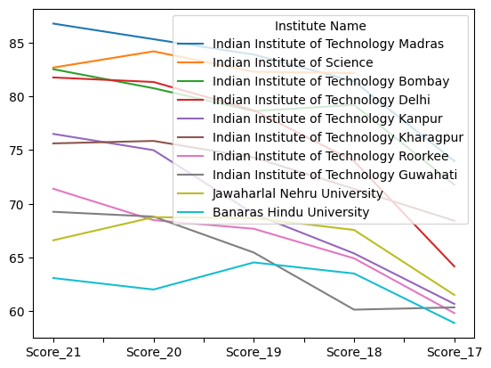

```python
base_dir = "D:/SEMESTER 5/DAV/NirfRanking_2016-2021/"
df = pd.read_csv(f'{base_dir}/OverallRanking.csv')
df_scores = df[['Institute Name', 'Score_21', 'Score_20', 'Score_19', 'Score_18', 'Score_17']]
fig = df_scores.head(10).set_index('Institute Name').T.plot()
# fig.update_layout(width=1000, height=500)
fig.show()
```

#### Query2: what is the performance of Bottom 10 institute's during 2016-2021?

[output not shown]

[figure not shown]

```python
df_scores.loc[:,'Nan'] = df_scores.isnull().sum(axis=1)
df_scores = df_scores[df_scores['Nan'] < 4]
df_scores.reset_index(inplace=True, drop=True)
df_scores = df_scores.drop(columns='Nan', axis=1)
fig = df_scores.tail(10).set_index('Institute Name').T.plot()
fig.update_layout(width=1000, height=500)
fig.show()
```

#### Query3: what is the performance of IIT's from 2016-2021 ?

[output not shown]

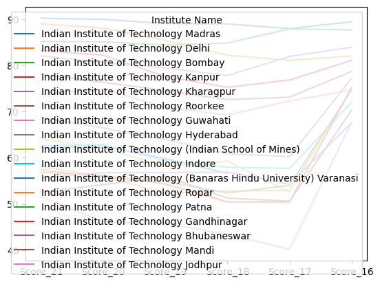

```python
df = pd.read_csv(f'{base_dir}/EngineeringRanking.csv')
df_scores = df[['Institute Name', 'Score_21', 'Score_20', 'Score_19', 'Score_18', 'Score_17', 'Score_16']]
df_scores.loc[:,'Nan'] = df_scores.isnull().sum(axis=1)
df_scores = df_scores[df_scores['Nan'] < 4]
df_scores.reset_index(inplace=True, drop=True)
df_scores = df_scores.drop(columns='Nan', axis=1)
sp_df = df_scores[df_scores['Institute Name'].str.contains('Indian Institute of Technology')]
fig = sp_df.set_index('Institute Name').T.plot()
# plt.suptitle("IIT's Performance (2016-2021)")
fig.show()
```

#### Conclusion :

1. There is sudden fallen of performance is coming in 2017.
2. But some Top IIT's Maintain there performance in 2017 like :- IIT Bombay , IIT madras etc.
3. After 2017,There are most of the IIT's are come back and there performance Increase.

#### Query4: what is the performance of NIT's from 2016-2021 ?

[output not shown]

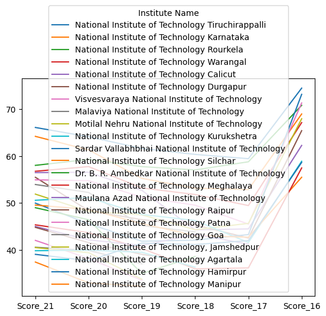

```python
sp_df = df_scores[df_scores['Institute Name'].str.contains('National Institute of Technology')]
fig = sp_df.set_index('Institute Name').T.plot()
# plt.suptitle("NIT's Performance (2016-2021)")
fig.show()
```

#### Conclusion :

1. There is sudden fallen of performance is coming in 2017.
2. After 2017,There are most of the IIT's are come back and there Nirf Score Increase.
3. some New NIT's are also added in between a year of 2018-2019

#### Query5: Changes in Educational Growth of Different States on basis of there Institue's NIRF Score Rank improves or vice versa ?

```python
df = pd.read_csv(f'{base_dir}/OverallRanking.csv')
df.loc[:,'Nan'] = df.isnull().sum(axis=1)
df = df[df['Nan'] < 3]
df.reset_index(inplace=True, drop=True)
df = df.drop(columns='Nan', axis=1)
df_Score = pd.DataFrame()
df_Score['2017'] = df['Score_17'].groupby(df['State']).sum()
df_Score['2018'] = df['Score_18'].groupby(df['State']).sum()
df_Score['2019'] = df['Score_19'].groupby(df['State']).sum()
df_Score['2020'] = df['Score_20'].groupby(df['State']).sum()
df_Score['2021'] = df['Score_21'].groupby(df['State']).sum()
df_Score.head()
```

| State | 2017 | 2018 | 2019 | 2020 | 2021 |
| --- | --- | --- | --- | --- | --- |
| Andhra Pradesh | 41.48 | 43.44 | 44.88 | 46.14 | 42.78 |
| Assam | 148.57 | 153.60 | 159.51 | 161.12 | 160.35 |
| Bihar | 39.87 | 44.25 | 46.28 | 48.09 | 47.67 |
| Chandigarh | 43.13 | 50.94 | 51.25 | 50.24 | 50.31 |
| Delhi | 277.67 | 306.72 | 314.76 | 319.93 | 310.39 |

#### Query6: What is the Mean/Average values of TLR, RPC, GO, OI, Perception for each year?

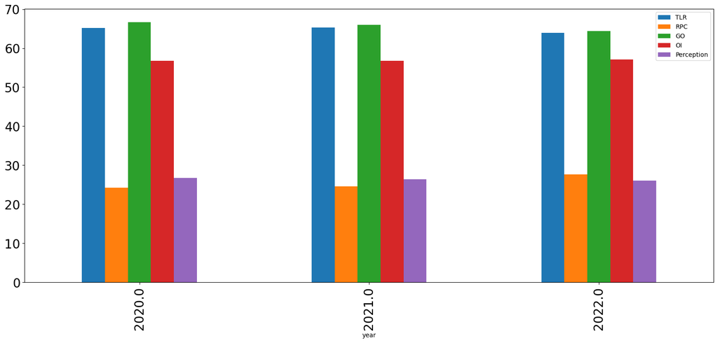

```python
data = pd.read_csv(f'{base_dir}/Final_Dataset.csv')
data['year']=pd.DatetimeIndex(data['Accreditation valid up to']).year
data_all_year=data[['year','TLR','RPC','GO','OI','Perception']]
data_all_parameter=data_all_year.groupby('year').mean()
data_all_parameter.plot(figsize=(20,8),fontsize=20,linewidth=10,kind = 'bar')
```

#### Conclusion : it basically gives an an broad idea about the indian Education System.

#### Query7: What is the distribution of Collages between the states Across India ?

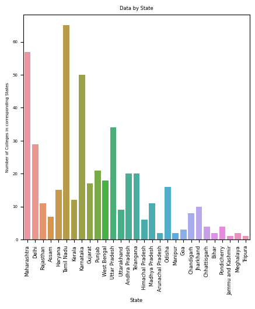

```python
plt.figure(figsize=(5,5))
ax=sns.countplot(data['State'])
plt.title(f'Data by State',fontsize=6)
plt.xticks(rotation='vertical',fontsize=6)
plt.yticks(fontsize=5)
plt.xlabel('State',fontsize=6)
plt.ylabel('Number of Colleges in corresponding States',fontsize=5)
plt.show()
```

#### Query8: what is the various Co-relation between the various factors of the ranking ?

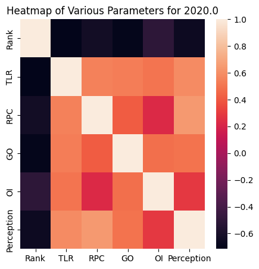

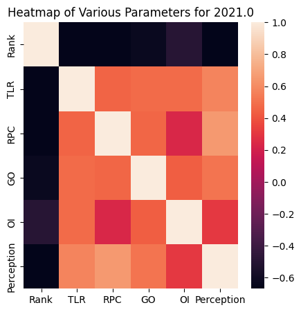

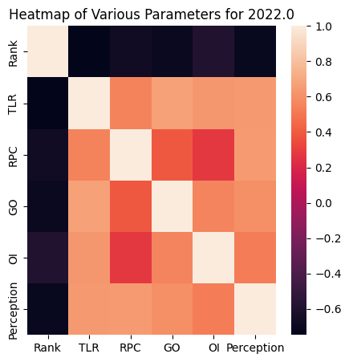

```python
plt.rcParams['figure.figsize'] = [5,5]
k=['Rank','TLR','RPC','GO','OI','Perception']
for i,j in data.groupby('year'):
    plt.title(f"Heatmap of Various Parameters for {i}")
    sns.heatmap(j[k].corr())
    plt.show()
```

#### Conclusion: This Shows that how different factors are varying and how to corelated with each other.

#### Query9: what is the Top Colleges in each domain of study on the basis of rank ?

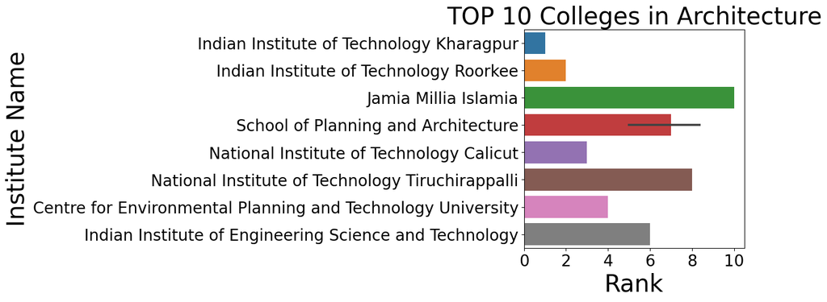

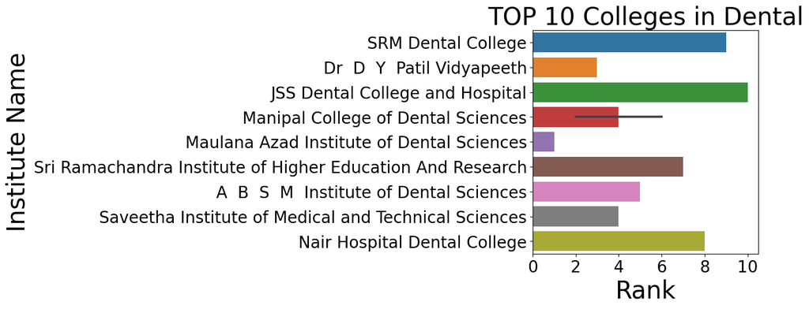

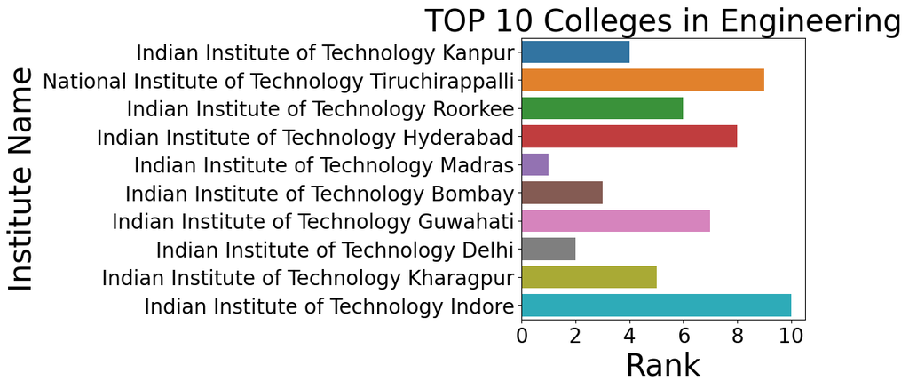

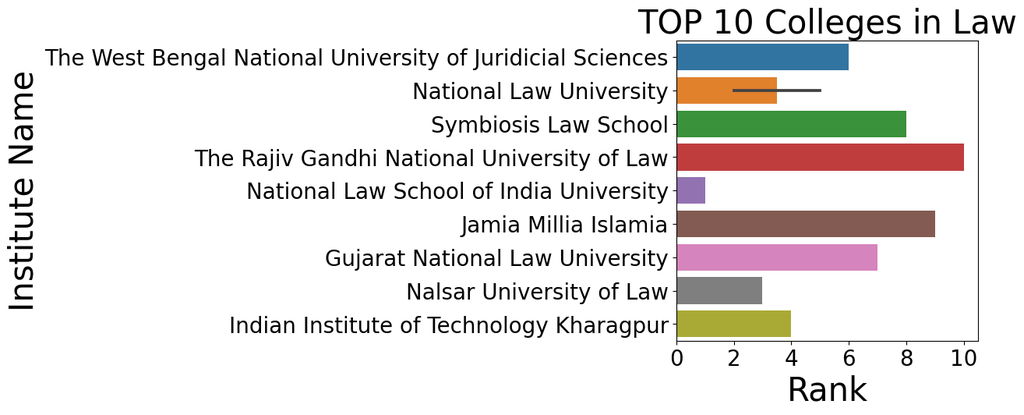

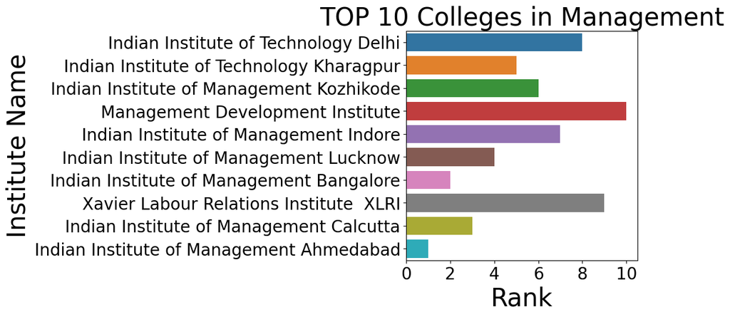

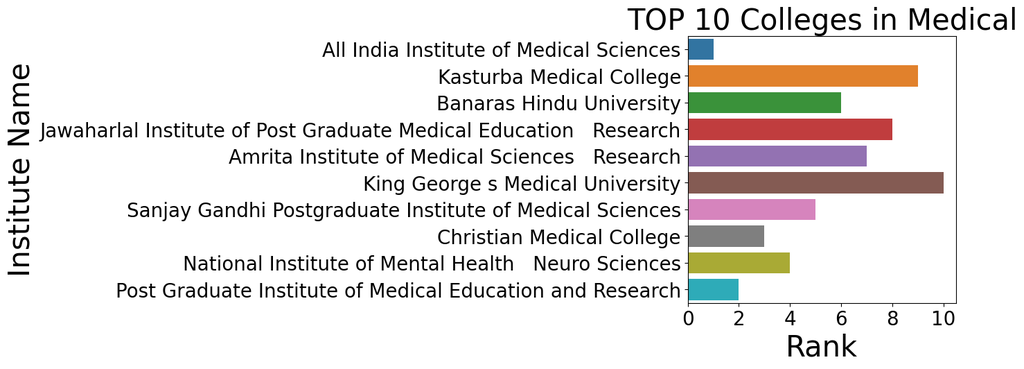

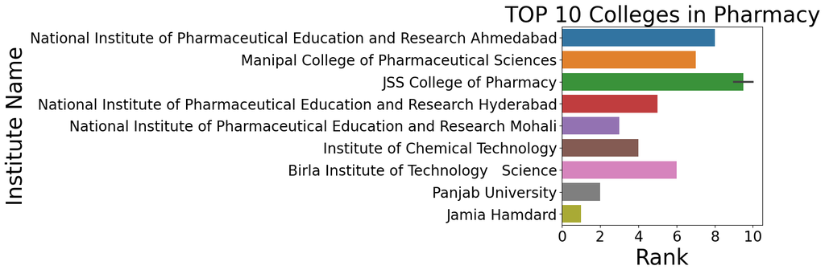

```python
top10Colleges = data.query("Rank <= 10")
for i,j in top10Colleges.groupby('Domain'):
    sns.barplot(j['Rank'],j['Name'],label=f"{i}")
    plt.title(f"TOP 10 Colleges in {i}",fontsize=30)
    plt.ylabel('Institute Name',fontsize=30)
    plt.xlabel("Rank",fontsize=30)
    plt.xticks(fontsize = 20)
    plt.yticks(fontsize = 20)
    plt.show()
```

```python
df = pd.read_csv(f'{base_dir}/UniversityRanking.csv')
df.head()
```

|  | Institute Id | Institute Name | City | State | Score_21 | Rank_21 | TLR_21 | RPC_21 | GO_21 | OI_21 | ... | GO_17 | OI_17 | Perception_17 | Score_16 | Rank_16 | TLR_16 | RPC_16 | GO_16 | OI_16 | Perception_16 |
| --- | --- | --- | --- | --- | --- | --- | --- | --- | --- | --- | --- | --- | --- | --- | --- | --- | --- | --- | --- | --- | --- |
| 0 | IR-O-U-0220 | Indian Institute of Science | Bengaluru | Karnataka | 82.67 | 1.0 | 79.13 | 91.48 | 78.23 | 58.39 | ... | NaN | NaN | NaN | 91.81 | 1 | 94.45 | 96.12 | 100.0 | 67.18 | 100.0 |
| 1 | IR-O-U-0109 | Jawaharlal Nehru University | New Delhi | Delhi | 67.99 | 2.0 | 71.19 | 44.96 | 95.07 | 73.36 | ... | 98.71 | 82.40 | 47.27 | 86.45 | 3 | 89.45 | 84.33 | 100.0 | 73.57 | 98.0 |
| 2 | IR-O-U-0500 | Banaras Hindu University | Varanasi | Uttar Pradesh | 64.02 | 3.0 | 64.50 | 45.00 | 100.00 | 53.13 | ... | 94.36 | 62.97 | 44.01 | 81.22 | 7 | 70.28 | 81.11 | 92.6 | 87.75 | 99.0 |
| 3 | IR-O-U-0570 | Calcutta University | Kolkata | West Bengal | 62.06 | 4.0 | 66.20 | 43.92 | 91.72 | 60.98 | ... | 95.76 | 39.02 | 17.15 | NaN | NaN | NaN | NaN | NaN | NaN | NaN |
| 4 | IR-O-U-0436 | Amrita Vishwa Vidyapeetham | Coimbatore | Tamil Nadu | 61.23 | 5.0 | 64.23 | 54.33 | 71.35 | 65.54 | ... | 65.77 | 82.17 | 26.12 | 74.02 | 14A | 74.39 | 69.03 | 100.0 | 74.02 | 80.0 |

5 rows × 46 columns

#### Conclusion: there are many University in India whose Score Very well and compete IIt's and Nit's.

#### Query11: Graduation Outcomes on the basis of different Domain ?

```python
GO_Domain = data.groupby('Domain')['GO'].sum()
GO_Domain
```

```
Domain
Architecture     1559.63
Dental           2436.89
Engineering     11340.72
Law              1310.91
Management       5928.82
Medical          3192.65
Pharmacy         4674.33
Name: GO, dtype: float64
```

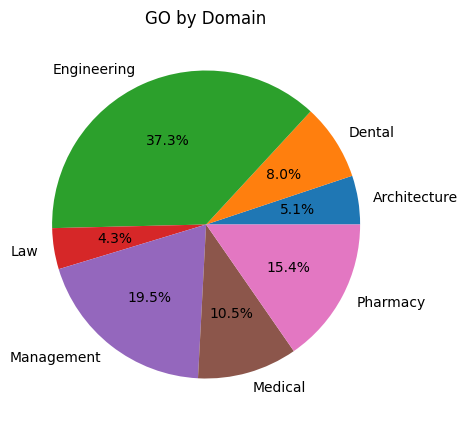

```python
GO_Domain.plot.pie(autopct = '%1.1f%%')
plt.title('GO by Domain')
plt.ylabel('')
```

#### Conclusion :So there are maximum colleges in Engineering domain are having highest Share on GO and minimum is Law and Architecture.

#### Query12: Analysis of participation of colleges in ranking process

```
year
2020.0    156
2021.0    148
2022.0     83
Name: Institute_ID, dtype: int64
```

```
(array([  0.,  20.,  40.,  60.,  80., 100., 120., 140., 160., 180.]),
 [Text(0, 0, ''),
```

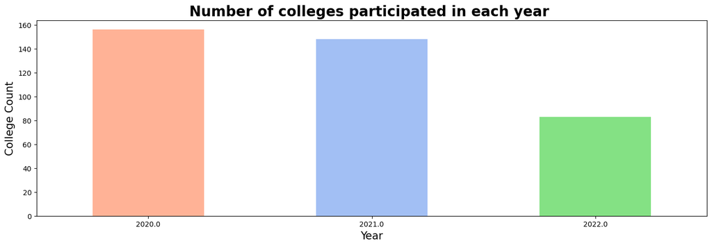

```python
# count of Colleges participated in each year
count_college= data.groupby('year')['Institute_ID'].nunique()
print(count_college)

# Bar plot for the No. of Colleges participated in each Season
count_college.plot.bar(color=[ 'coral', 'cornflowerblue', 'limegreen'], figsize=(17,5), alpha=0.6)
plt.title("Number of colleges participated in each year ",fontsize=20,fontweight="bold")
plt.ylabel("College Count", size = 15)
plt.xlabel("Year", size = 15)
plt.xticks(size = 10, rotation='horizontal')
plt.yticks(size = 10)
```

#### Conclusion : So the maximum colleges participated in year 2020.

#### Query13 : Top Colleges in each domain of study on the basis of Teacher and Learning Resource

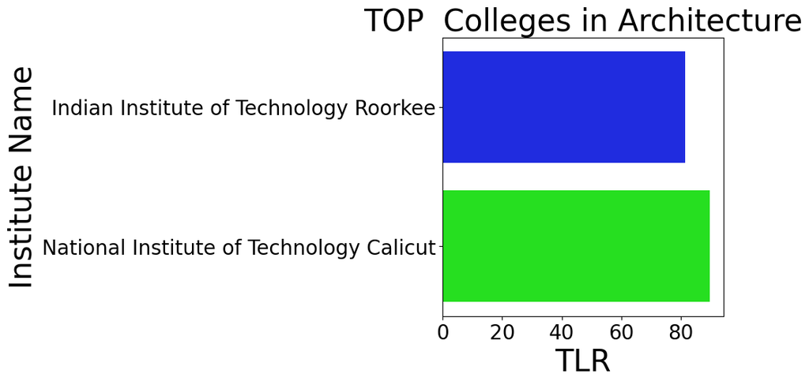

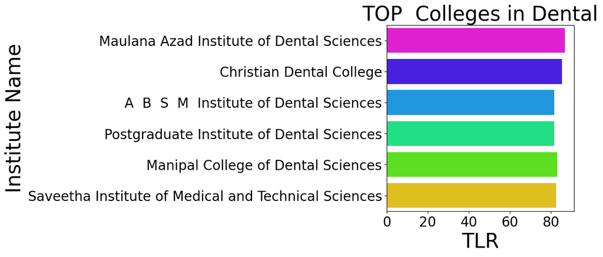

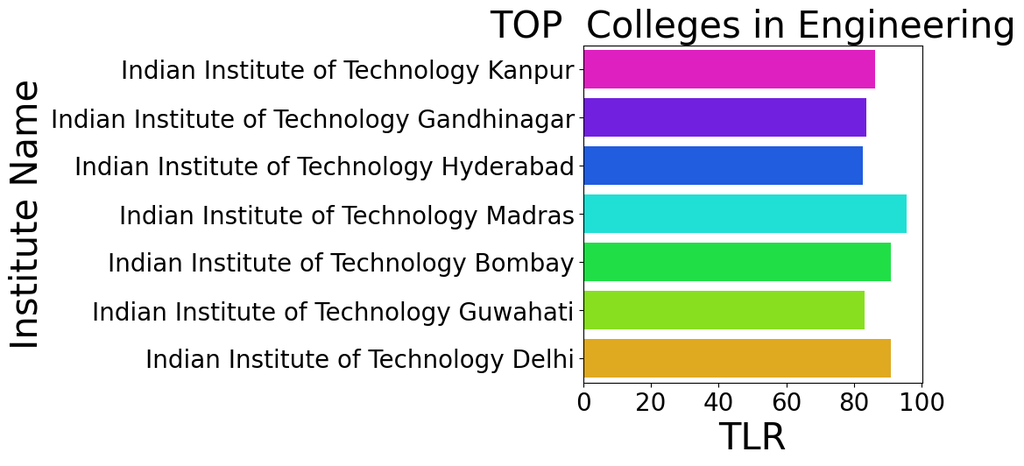

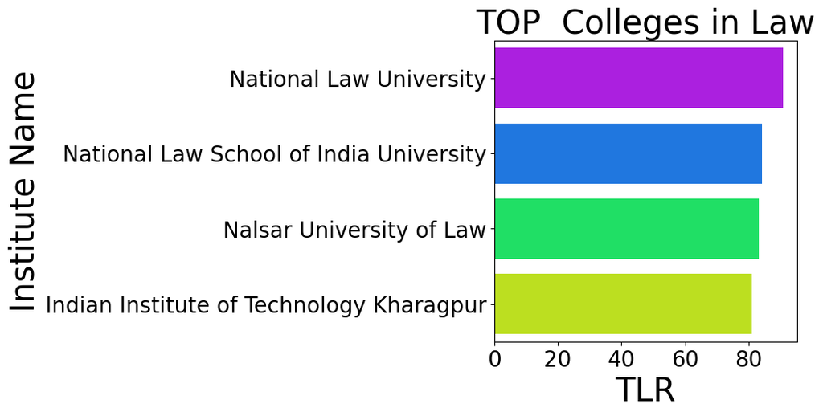

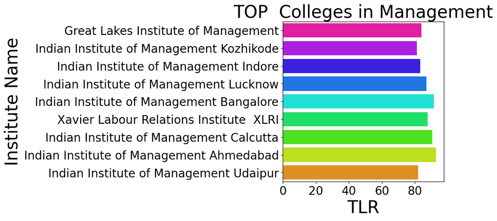

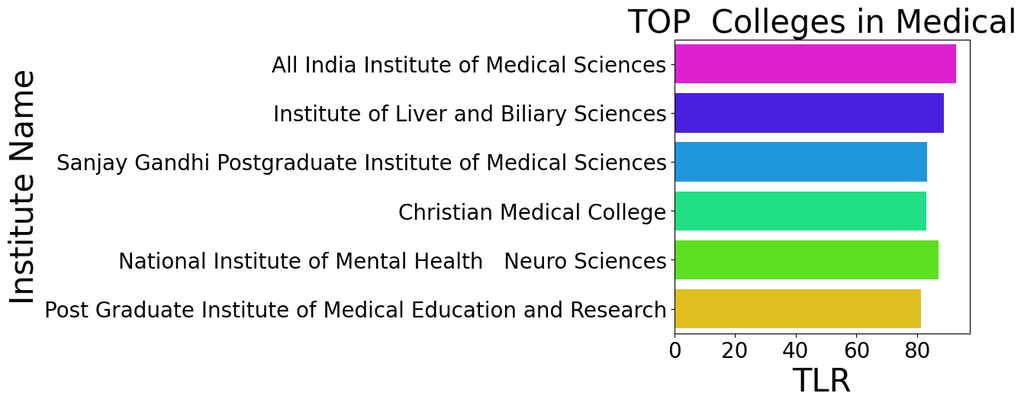

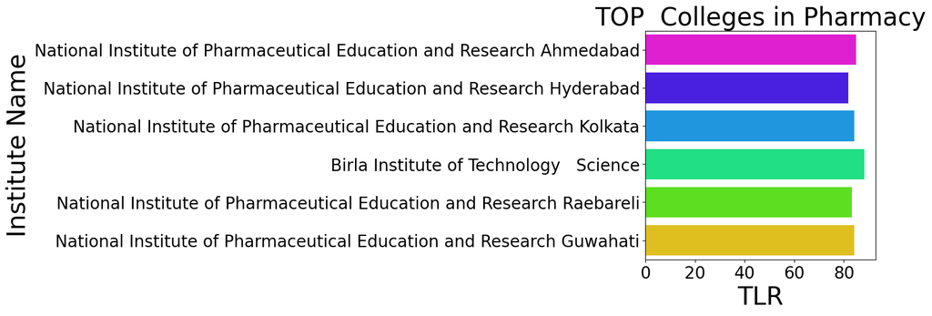

```python
# data=pd.read_csv("C:/Users/HP/Downloads/Final_Dataset.csv")
data = pd.read_csv(f'{base_dir}/Final_Dataset.csv')
top10data = data.query("TLR >= 80")
for i,j in top10data.groupby('Domain'):
    sns.barplot(j['TLR'],j['Name'],label=f"{i}",palette='hsv_r')
    plt.title(f"TOP  Colleges in {i}",fontsize=30)
    plt.ylabel('Institute Name',fontsize=30)
    plt.xlabel("TLR",fontsize=30)
    plt.xticks(fontsize = 20)
    plt.yticks(fontsize = 20)
    plt.show()
```

#### Query14 : Colleges whoose perception is zero

```python
zero_perc=data.loc[data['Perception']==0]
zero_perc[['Institute_ID','Name']]
```

|  | Institute_ID | Name |
| --- | --- | --- |
| 7 | IR-E-U-0332 | The Rashtrasant Tukadoji Maharaj Nagpur Univer... |
| 35 | IR-E-C-19650 | Vardhaman College of Engineering |
| 50 | IR-E-C-18254 | Yeshwantrao Chavan College of Engineering |
| 68 | IR-E-C-1345 | P E S College of Engineering |
| 117 | IR-M-U-0379 | Lovely Professional University |
| 189 | IR-P-U-0190 | Shoolini University of Biotechnology and Manag... |
| 229 | IR-E-U-0604 | Amity University Gwalior |
| 237 | IR-E-C-34167 | Ramrao Adik Institute of Technology |
| 241 | IR-E-C-16537 | St Josephs College of Engineering |
| 261 | IR-E-U-0163 | The Northcap University |
| 290 | IR-M-U-0373 | Chitkara University |
| 304 | IR-N-U-0461 | M G R Educational and Research Institute |
| 310 | IR-E-C-1398 | BNM Institute of Technology |
| 319 | IR-P-U-0491 | Vels Institute of Science Technology Advanc... |
| 325 | IR-E-U-0190 | Shoolini University of Biotechnology and Manag... |
| 366 | IR-E-U-0373 | Chitkara University |
| 386 | IR-P-U-0085 | Guru Ghasidas Vishwavidyalaya |
| 389 | IR-N-N-116 | Pacific Dental College |
| 406 | IR-E-U-0535 | Rajiv Gandhi Institute of Petroleum Technology |
| 422 | IR-E-C-26929 | Sree Vidyanikethan Engineering College |

```python
north=[ 'Himachal Pradesh', 'Punjab', 'Uttarakhand' ,'Delhi', 'Uttar Pradesh' , 'Haryana']
east=[ 'Bihar', 'Orissa', 'Jharkhand',  'West Bengal']
west= ['Rajasthan' , 'Gujarat', 'Goa' , 'Maharashtra']
south=['Andhra Pradesh', 'Karnataka', 'Kerala' , 'Tamil Nadu']
central=['Madhya Pradesh', 'Chattisgarh']
northeast=['Assam', 'Sikkim', 'Nagaland', 'Meghalaya', 'Manipur', 'Mizoram', 'Tripura' , 'Arunachal Pradesh']
for i in data['State']:
    print(i,"in for")
    if  i in north:
        print(i,data['State'])
        data['zone']='north'
    elif i in east:
        data['zone']='east'
    elif i in west:
        data['zone']='west'
    elif i in south:
        data['zone']='south'
    else:
        data['zone']='undetermined'
# elif data['State'] in central:
#     data['zone']='central'
# elif data['State'] in northeast:
#     data['zone']='northeast'
data[['zone','State']]
```

[output not shown]

[output cut: 1773 more lines]

[output not shown]

|  | zone | State |
| --- | --- | --- |
| 0 | west | Maharashtra |
| 1 | west | Maharashtra |
| 2 | west | Maharashtra |
| 3 | west | Delhi |
| 4 | west | Maharashtra |
| ... | ... | ... |
| 455 | west | Uttar Pradesh |
| 456 | west | Andhra Pradesh |
| 457 | west | Uttar Pradesh |
| 458 | west | Karnataka |
| 459 | west | Goa |

460 rows × 2 columns

```python
data=pd.read_csv(f'{base_dir}/Final_Dataset.csv')
data['year']=pd.DatetimeIndex(data['Accreditation valid up to']).year
Eng_Clg = data[data['Domain']=='Engineering']
Mng_Clg = data[data['Domain']=='Management']
```

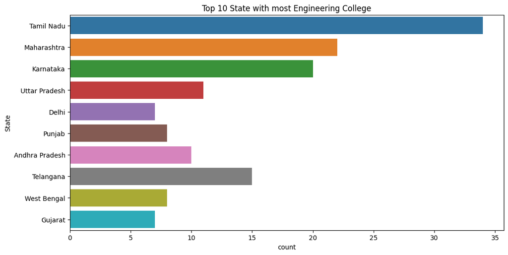

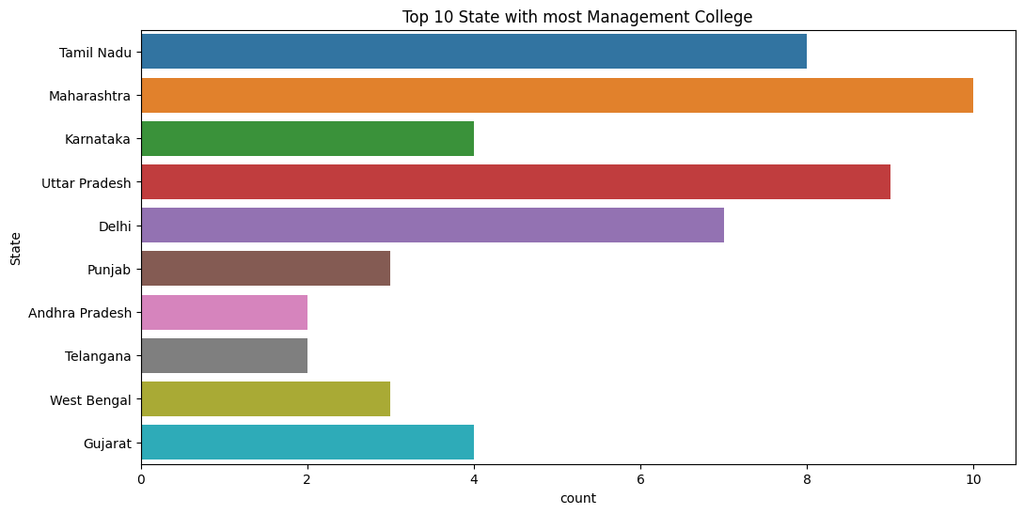

```python
plt.figure(figsize=(12,6))
sns.countplot(y='State',order = data['State'].value_counts().index[0:10],data=Eng_Clg)
plt.title('Top 10 State with most Engineering College')

plt.figure(figsize=(12,6))
sns.countplot(y='State',order = data['State'].value_counts().index[0:10],data=Mng_Clg)
plt.title('Top 10 State with most Management College')
```

#### Query -17: Colleges appearing max times in ranking

```python
data.Name.value_counts().head(10)
```

```
Panjab University                                   5
Aligarh Muslim University                           5
Jamia Millia Islamia                                5
Kalinga Institute of Industrial Technology          5
Birla Institute of Technology                       4
Indian Institute of Technology Kharagpur            4
National Institute of Technology Tiruchirappalli    3
Lovely Professional University                      3
Indian Institute of Technology Roorkee              3
Institute of Management Technology                  3
Name: Name, dtype: int64
```

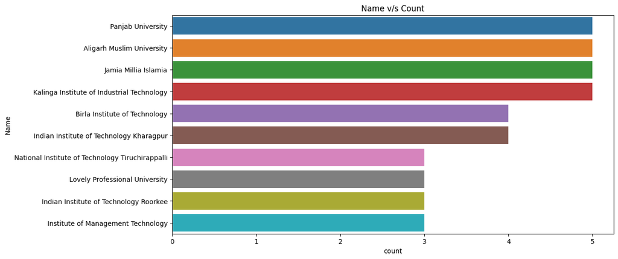

```python
plt.figure(figsize=(12,6))
sns.countplot(y='Name',order = data['Name'].value_counts().index[0:10],data=data)
plt.title('Name v/s Count')
```

#### Conclusion:

1.Panjab University,AMU,JMI,KIIT appered most times i.e. 5 in ranking .This means they were among top ranked in different domains 5 times.

#### Query-18 : Distribution of various parameters over the years

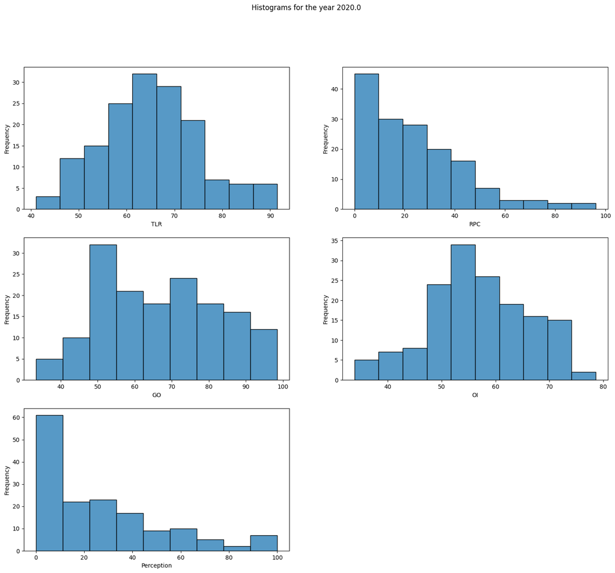

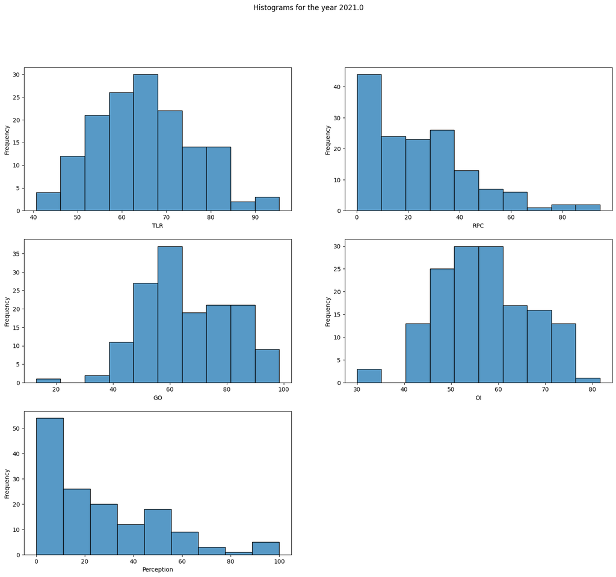

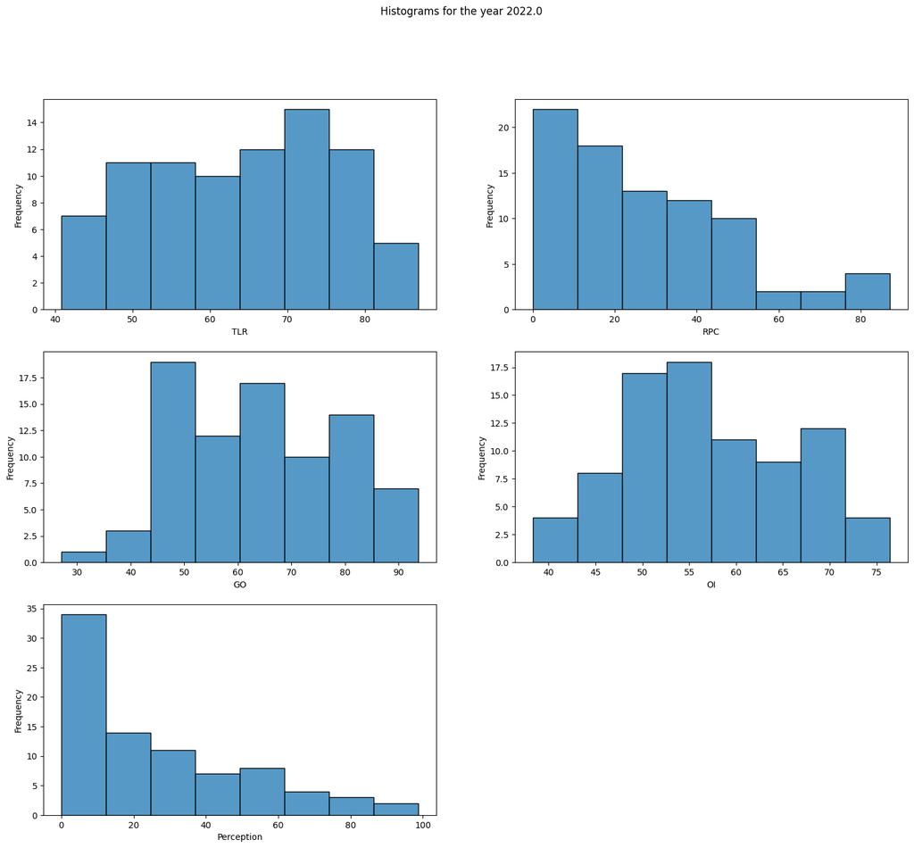

```python
plt.rcParams['figure.figsize'] = [18,15]
for i,j in data.groupby('year'):
  cols=['Rank','TLR','RPC','GO','OI','Perception']
  stat_data = j[cols]
  cols =['TLR','RPC','GO','OI','Perception']
  plt.figure()
  plt.suptitle(f"Histograms for the year {i}")
  for k in range(len(cols)):
    plt.subplot(3,2,k+1)
    sns.histplot(stat_data[cols[k]], bins='auto')
    plt.xlabel(f"{cols[k]}")
    plt.ylabel(f"Frequency")
  plt.show()
```